# Stat 420 Final Project Work - EDA

Shashank Thakur, Net ID: sthakur5

24th July 2022

Set parameters and load any libraries to be used.

## Explorartory Data Analysis

We will first read the data file to be used for this project.

```r
ca_housing_data = read.csv('../000_Data/california-housing-prices/housing.csv')
head(ca_housing_data)
```

```
##   longitude latitude housing_median_age total_rooms total_bedrooms population
## 1    -122.2    37.88                 41         880            129        322
## 2    -122.2    37.86                 21        7099           1106       2401
## 3    -122.2    37.85                 52        1467            190        496
## 4    -122.2    37.85                 52        1274            235        558
## 5    -122.2    37.85                 52        1627            280        565
## 6    -122.2    37.85                 52         919            213        413
##   households median_income median_house_value ocean_proximity
## 1        126         8.325             452600        NEAR BAY
## 2       1138         8.301             358500        NEAR BAY
## 3        177         7.257             352100        NEAR BAY
## 4        219         5.643             341300        NEAR BAY
## 5        259         3.846             342200        NEAR BAY
## 6        193         4.037             269700        NEAR BAY
```

Lets understand some of the high level summary of columns in the data set:

```r
str(ca_housing_data)
```

```
## 'data.frame':    20640 obs. of  10 variables:
##  $ longitude         : num  -122 -122 -122 -122 -122 ...
##  $ latitude          : num  37.9 37.9 37.9 37.9 37.9 ...
##  $ housing_median_age: num  41 21 52 52 52 52 52 52 42 52 ...
##  $ total_rooms       : num  880 7099 1467 1274 1627 ...
##  $ total_bedrooms    : num  129 1106 190 235 280 ...
##  $ population        : num  322 2401 496 558 565 ...
##  $ households        : num  126 1138 177 219 259 ...
##  $ median_income     : num  8.33 8.3 7.26 5.64 3.85 ...
##  $ median_house_value: num  452600 358500 352100 341300 342200 ...
##  $ ocean_proximity   : chr  "NEAR BAY" "NEAR BAY" "NEAR BAY" "NEAR BAY" ...
```

Original data set has 20640 rows and 10 variables.

If we omit any rows with missing data, what is the impact?

```r
str(na.omit(ca_housing_data))
```

```
## 'data.frame':    20433 obs. of  10 variables:
##  $ longitude         : num  -122 -122 -122 -122 -122 ...
##  $ latitude          : num  37.9 37.9 37.9 37.9 37.9 ...
##  $ housing_median_age: num  41 21 52 52 52 52 52 52 42 52 ...
##  $ total_rooms       : num  880 7099 1467 1274 1627 ...
##  $ total_bedrooms    : num  129 1106 190 235 280 ...
##  $ population        : num  322 2401 496 558 565 ...
##  $ households        : num  126 1138 177 219 259 ...
##  $ median_income     : num  8.33 8.3 7.26 5.64 3.85 ...
##  $ median_house_value: num  452600 358500 352100 341300 342200 ...
##  $ ocean_proximity   : chr  "NEAR BAY" "NEAR BAY" "NEAR BAY" "NEAR BAY" ...
##  - attr(*, "na.action")= 'omit' Named int [1:207] 291 342 539 564 697 739 1098 1351 1457 1494 ...
##   ..- attr(*, "names")= chr [1:207] "291" "342" "539" "564" ...
```

Next I would like to check the range of values for `median_house_value`:

```r
summary(ca_housing_data$median_house_value)
```

```
##    Min. 1st Qu.  Median    Mean 3rd Qu.    Max.
##   14999  119600  179700  206856  264725  500001
```

```r
var(ca_housing_data$median_house_value)
```

```
## [1] 1.332e+10
```

The `median_house_value` varies a lot from range 14K to 500K and has a very high variance. We may have to transform this variable before fitting.

Are any values missing for `median_house_value`?

```r
anyNA(ca_housing_data$median_house_value)
```

```
## [1] FALSE
```

Good news is that none of values for `median_house_value` is missing.

What are the unique values for `ocean_proximity` variable in our dataset?

```r
unique(ca_housing_data$ocean_proximity)
```

```
## [1] "NEAR BAY"   "<1H OCEAN"  "INLAND"     "NEAR OCEAN" "ISLAND"
```

```r
is.factor(ca_housing_data$ocean_proximity)
```

```
## [1] FALSE
```

The variable `ocean_proximity` has 5 unique *character* values and is not a factor variable. We may have to coerce this variable into factor variable and transform to a numeric levels to allow for proper modeling.

I am curious about the relative distribution of houses with respect to ocean proximity.

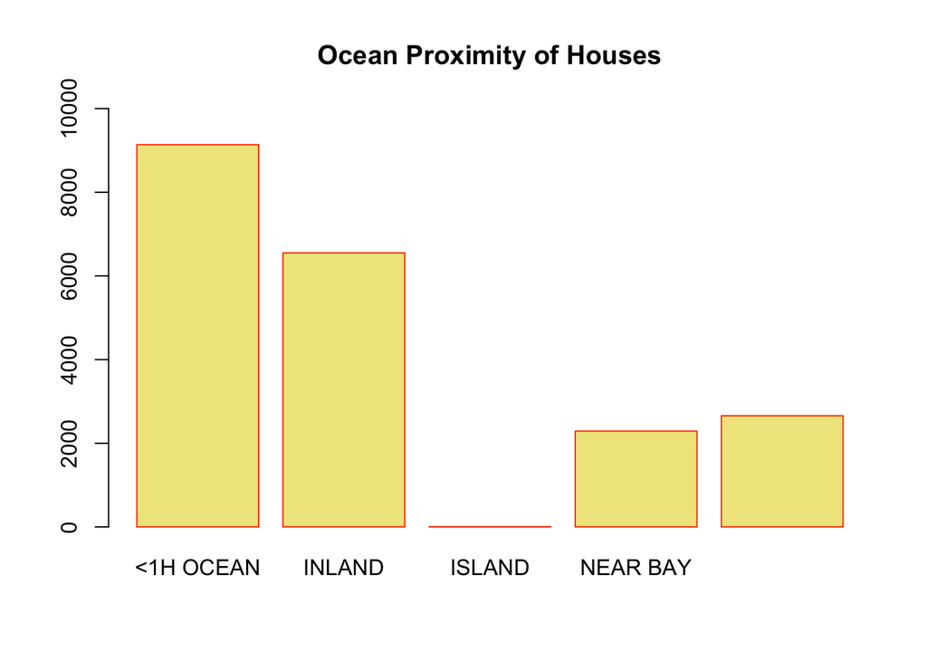

```r
barplot(table(ca_housing_data$ocean_proximity),
        main = "Ocean Proximity of Houses",
        col = "khaki",
        border = "orangered",
        ylim = c(0, 10000))
```

It seems there aren’t many houses on island in our data set and it may be prudent to just drop that category all together from `ocean_proximity`.

Lets check on distribution of `total_rooms`:

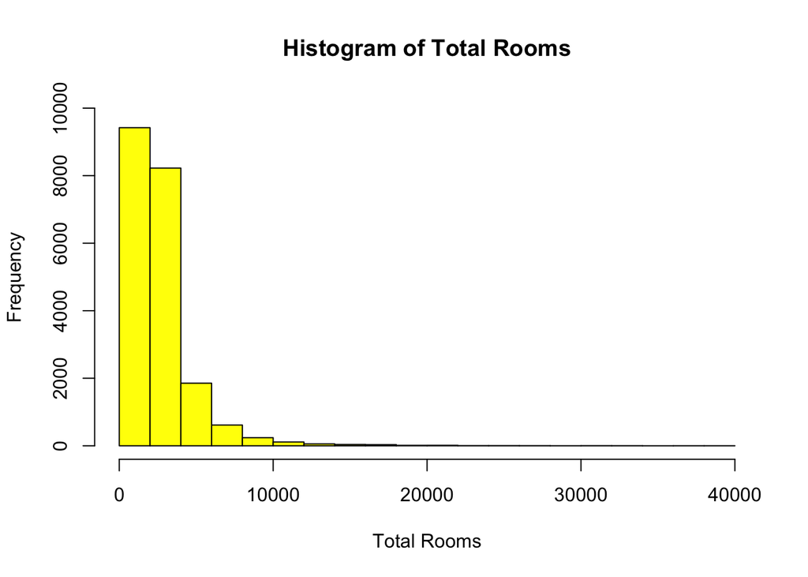

```r
hist(ca_housing_data$total_rooms,
     main = "Histogram of Total Rooms",
     xlab = "Total Rooms",
     col = "yellow",
     ylim = c(0, 10000))
```

`total_rooms` is highly skewed to right and may need some transformation to make is useful predictor.

I would like to plot the `median_house_value` relative to the number of bedrooms and check if there is any trend in data?

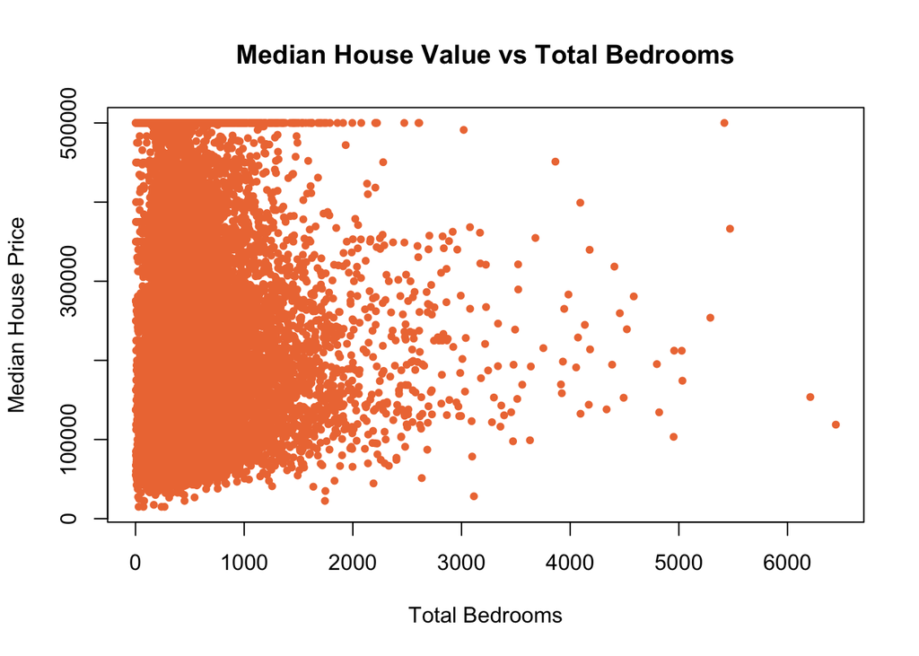

```r
plot(median_house_value ~ total_bedrooms, data = ca_housing_data,
     main = "Median House Value vs Total Bedrooms",
     col = "sienna2",
     cex = 1,
     pch = 20,
     xlab = "Total Bedrooms",
     ylab = "Median House Price")
```

From the scatterplot it is evident that prices of house cannot be explained by the number of bedrooms. There seems be few outliers and may have to run additional diagnostics to figure out if it is problematic and needs to be addressed during modeling of data.

Lets check the variance inflation factor in the variables. To process this I will fit a simple linear model with all variables and response `median_house_value`.

```r
simple_cahou_model = lm(median_house_value ~ ., data = ca_housing_data)
vif(simple_cahou_model)
```

```
##                 longitude                  latitude        housing_median_age
##                    18.091                    19.969                     1.324
##               total_rooms            total_bedrooms                population
##                    12.966                    36.310                     6.446
##                households             median_income     ocean_proximityINLAND
##                    35.173                     1.786                     2.860
##     ocean_proximityISLAND   ocean_proximityNEAR BAY ocean_proximityNEAR OCEAN
##                     1.002                     1.567                     1.197
```

```r
names(vif(simple_cahou_model) > 5)
```

```
##  [1] "longitude"                 "latitude"
##  [3] "housing_median_age"        "total_rooms"
##  [5] "total_bedrooms"            "population"
##  [7] "households"                "median_income"
##  [9] "ocean_proximityINLAND"     "ocean_proximityISLAND"
## [11] "ocean_proximityNEAR BAY"   "ocean_proximityNEAR OCEAN"
```

Based on sheer number of correlated predictors, we have to make some good decision while selecting predictors.